# Report2_Exploring Data

Salvador Osuna-Caballero

6/12/2021

## Introduction

The data has been previously defined. In summary we have 4 ENV (three field seasons plus one screening in controlled condition). Here we explore the data to made some correlations, visualize them and check the normality assumptions (to transform the values if they need it).

## Explore data

### Load the necessary packages

```r
# Check if it is neccesary install the packages
list.of.packages <- c("tidyverse",
"ggpubr",
"ggstatsplot",
"openintro",
"rstatix",
"DescTools",
"WRS2",
"metan")

new.packages <- list.of.packages[!(list.of.packages %in%
installed.packages()[,"Package"])]

if(length(new.packages)) install.packages(new.packages)

library(tidyverse) # manipulation and data visualization
library(ggpubr) # dummy graphs
library(ggstatsplot) # fancy graphs
library(rstatix) # tests P/NP
library(DescTools) #Yuen robust test
library(WRS2) # robust effect size
library(metan) #to rid the alpha lattice design
library(openxlsx)#read excel files
library(readxl)
```

### Load the data

```r
#season 2018
R18_nc <- read_excel("C:/Users/Salva/Documents/GitHub/Genomic-Selection/Genomic Selection_SALVA/data/R18_19_20.xlsx",
                     sheet = "R18_nc",
                     col_types =
                       c("text", #ENV
                         "text", #REP
                         "text", #BLOCK
                         "numeric", #ROW
                         "text", #Material
                         "text", #Specie
                         "text", #GEN
                         "numeric", #GERM
                         "numeric", #DtF
                         "numeric", #DtP
                         "numeric", #GDD_F
                         "numeric", #GDD_P
                         "numeric", #biomass_pl
                         "numeric", #yield_pl
                         "numeric", #yield_KgHa
                         "numeric", #Asco_adj
                         "numeric", #Rust
                         "numeric", #Rust_adj
                         "numeric" #Oidio
                       ))
R18_nc$ENV <- as.factor(R18_nc$ENV)
R18_nc$REP <- as.factor(R18_nc$REP)
R18_nc$BLOCK <- as.factor(R18_nc$BLOCK)
R18_nc$ROW <- as.factor(R18_nc$ROW)
R18_nc$Material <- as.factor(R18_nc$Material)
R18_nc$Specie <- as.factor(R18_nc$Specie)
R18_nc$GEN <- as.factor(R18_nc$GEN)

#season 2019
R19_nc <- read_excel("C:/Users/Salva/Documents/GitHub/Genomic-Selection/Genomic Selection_SALVA/data/R18_19_20.xlsx",
                     sheet = "R19_nc",
                     col_types =
                       c("text", #ENV
                         "text", #REP
                         "text", #BLOCK
                         "numeric", #ROW
                         "text", #Material
                         "text", #Specie
                         "text", #GEN
                         "numeric", #GERM
                         "numeric", #GDD_FF
                         "numeric", #GDD_F
                         "numeric", #GDD_FP
                         "numeric", #GDD_P
                         "numeric", #GDD_M
                         "numeric", #Rust
                         "numeric", #Rust_adj
                         "numeric", #Biom_pl_g
                         "numeric" #yield_pl_g
                       ))
R19_nc$ENV <- as.factor(R19_nc$ENV)
R19_nc$REP <- as.factor(R19_nc$REP)
R19_nc$BLOCK <- as.factor(R19_nc$BLOCK)
R19_nc$ROW <- as.factor(R19_nc$ROW)
R19_nc$Material <- as.factor(R19_nc$Material)
R19_nc$Specie <- as.factor(R19_nc$Specie)
R19_nc$GEN <- as.factor(R19_nc$GEN)
```

### Inspect the data

In this table we can consider to remove the outliers in case they are too extremes .

```r
inspect(R18_nc, plot = FALSE)
```

```
## # A tibble: 19 x 9
##    Variable      Class   Missing Levels Valid_n    Min  Median     Max Outlier
##    <chr>         <chr>   <chr>   <chr>    <int>  <dbl>   <dbl>   <dbl>   <dbl>
##  1 ENV           factor  No      1          969  NA      NA       NA        NA
##  2 REP           factor  No      3          969  NA      NA       NA        NA
##  3 BLOCK         factor  No      19         969  NA      NA       NA        NA
##  4 ROW           factor  No      19         969  NA      NA       NA        NA
##  5 Material      factor  No      5          969  NA      NA       NA        NA
##  6 Specie        factor  No      3          969  NA      NA       NA        NA
##  7 GEN           factor  No      323        969  NA      NA       NA        NA
##  8 GERM          numeric No      -          969   3      10       10        89
##  9 DtF           numeric No      -          969  77.4   112.     160.       25
## 10 DtP           numeric No      -          969  98.0   129.     175.       16
## 11 GDD_F         numeric No      -          969 318.    565.    1102.       48
## 12 GDD_P         numeric No      -          969 473.    714.    1329.       25
## 13 Biom_plant_g  numeric No      -          969   0      25.1     89.7      13
## 14 yield_plant_g numeric No      -          969   0       8.76    34.5       6
## 15 yield_kgHa    numeric No      -          969   0    2627.   10342.        6
## 16 Asco_Adj      numeric No      -          969   3.79   52.0    100         0
## 17 Rust          numeric No      -          969   2       8       40        35
## 18 Rust_adj      numeric No      -          969   1.28    8.89    50        48
## 19 Oidio         numeric No      -          969   0     100      100       116
```

```r
inspect(R19_nc, plot = FALSE)
```

```
## # A tibble: 17 x 9
##    Variable      Class   Missing Levels Valid_n   Min Median    Max Outlier
##    <chr>         <chr>   <chr>   <chr>    <int> <dbl>  <dbl>  <dbl>   <int>
##  1 ENV           factor  No      1          966  NA    NA      NA        NA
##  2 REP           factor  No      3          966  NA    NA      NA        NA
##  3 BLOCK         factor  No      19         966  NA    NA      NA        NA
##  4 ROW           factor  No      19         966  NA    NA      NA        NA
##  5 Specie        factor  No      5          966  NA    NA      NA        NA
##  6 Material      factor  No      6          966  NA    NA      NA        NA
##  7 GEN           factor  No      322        966  NA    NA      NA        NA
##  8 GERM_adj      numeric No      -          966   0     7.72   10        31
##  9 GDD_FF        numeric Yes     -          950 225.  549.   1096.       73
## 10 GDD_F         numeric Yes     -          952 301.  621.   1195.       73
## 11 GDD_FP        numeric Yes     -          952 331.  690    1330.       30
## 12 GDD_P         numeric Yes     -          952 382.  748.   1407.       29
## 13 GDD_M         numeric Yes     -          952 467.  870.   1407.       81
## 14 Rust          numeric No      -          966   0.5  10      55        26
## 15 Rust_adj      numeric No      -          966   0    10.1   100        61
## 16 Biom_plant_g  numeric No      -          966   0     9.77  112.       26
## 17 yield_plant_g numeric No      -          966   0     1.69   20.1      31
```

### Get the BLUPs and evaluate the assumptions

We get rid with the alpha lattice design obtaining the BLUP from the three replicates, considering also the block:

```r
gen_alphaR18 <-
  gamem(R18_nc,
        GEN,
        REP,
        resp = c("GERM", "DtF", "DtP", "GDD_F", "GDD_P", "Biom_plant_g", "yield_plant_g", "Asco_Adj", "Rust", "Rust_adj", "Oidio"),
        BLOCK)
```

```
## Evaluating trait GERM |====                                      | 9% 00:00:00
Evaluating trait DtF |========                                   | 18% 00:00:01
Evaluating trait DtP |============                               | 27% 00:00:01
Evaluating trait GDD_F |===============                          | 36% 00:00:02
Evaluating trait GDD_P |===================                      | 45% 00:00:03
Evaluating trait Biom_plant_g |===================               | 55% 00:00:03
Evaluating trait yield_plant_g |=====================            | 64% 00:00:04
Evaluating trait Asco_Adj |============================          | 73% 00:00:04
Evaluating trait Rust |==================================        | 82% 00:00:05
Evaluating trait Rust_adj |===================================   | 91% 00:00:05
Evaluating trait Oidio |=========================================| 100% 00:00:06
## ---------------------------------------------------------------------------
## P-values for Likelihood Ratio Test of the analyzed traits
## ---------------------------------------------------------------------------
##      model     GERM       DtF       DtP     GDD_F     GDD_P Biom_plant_g
##   Complete       NA        NA        NA        NA        NA           NA
##   Genotype 9.52e-37 4.06e-206 9.86e-178 7.12e-205 7.72e-188     3.30e-53
##  rep:block 2.87e-02  1.00e+00  1.00e+00  1.00e+00  1.00e+00     7.15e-01
##  yield_plant_g Asco_Adj     Rust Rust_adj    Oidio
##             NA       NA       NA       NA       NA
##       4.09e-57 1.30e-20 4.38e-11 2.16e-10 1.56e-29
##       1.00e+00 3.88e-01 1.00e+00 3.10e-02 1.00e+00
## ---------------------------------------------------------------------------
## All variables with significant (p < 0.05) genotype effect
```

```r
gen_alphaR19 <-
  gamem(R19_nc,
        GEN,
        REP,
        resp = c("GERM_adj", "GDD_FF", "GDD_F", "GDD_FP", "GDD_P", "Biom_plant_g", "yield_plant_g", "GDD_M", "Rust", "Rust_adj"),
        BLOCK)
```

```
## Evaluating trait GERM_adj |====                                  | 10% 00:00:00
Evaluating trait GDD_FF |========                                | 20% 00:00:01
Evaluating trait GDD_F |============                             | 30% 00:00:01
Evaluating trait GDD_FP |================                        | 40% 00:00:02
Evaluating trait GDD_P |====================                     | 50% 00:00:02
Evaluating trait Biom_plant_g |====================              | 60% 00:00:03
Evaluating trait yield_plant_g |=======================          | 70% 00:00:03
Evaluating trait GDD_M |=================================        | 80% 00:00:04
Evaluating trait Rust |======================================    | 90% 00:00:04
Evaluating trait Rust_adj |======================================| 100% 00:00:05
## ---------------------------------------------------------------------------
## P-values for Likelihood Ratio Test of the analyzed traits
## ---------------------------------------------------------------------------
##      model GERM_adj    GDD_FF     GDD_F    GDD_FP     GDD_P Biom_plant_g
##   Complete       NA        NA        NA        NA        NA           NA
##   Genotype 2.63e-21 1.83e-160 1.32e-159 4.31e-144 4.16e-116     2.23e-30
##  rep:block 8.09e-04  5.42e-03  1.35e-01  2.13e-06  7.48e-08     2.35e-01
##  yield_plant_g     GDD_M     Rust Rust_adj
##             NA        NA       NA       NA
##       1.84e-32 1.97e-139 1.51e-32 9.26e-11
##       8.10e-02  1.66e-04 9.14e-02 1.24e-05
## ---------------------------------------------------------------------------
## All variables with significant (p < 0.05) genotype effect
```

**Details of the analysis:**

```r
get_model_data(gen_alphaR18, "details")
```

```
## # A tibble: 6 x 12
##   Parameters GERM   DtF    DtP   GDD_F GDD_P Biom_plant_g yield_plant_g Asco_Adj
##   <chr>      <chr>  <chr>  <chr> <chr> <chr> <chr>        <chr>         <chr>
## 1 Ngen       323    323    323   323   323   323          323           323
## 2 OVmean     9.162  115.4~ 133.~ 609.~ 779.~ 27.1315      9.6975        52.3617
## 3 Min        3 (20~ 77.45~ 98.0~ 318.~ 473.~ 0 (25 in 6 ~ 0 (27 in 6 o~ 3.7913 ~
## 4 Max        10 (1~ 160.2~ 174.~ 1102~ 1329~ 89.6921 (14~ 34.474 (19 i~ 100 (2 ~
## 5 MinGEN     4.666~ 83.68~ 104.~ 361.~ 521.~ 1.3953 (317) 0.0385 (318)  9.6318 ~
## 6 MaxGEN     10 (1~ 157.6~ 171.~ 1065~ 1277~ 81.9236 (14~ 25.0754 (88)  88.4794~
## # ... with 3 more variables: Rust <chr>, Rust_adj <chr>, Oidio <chr>
```

```r
get_model_data(gen_alphaR19, "details")
```

```
## # A tibble: 6 x 11
##   Parameters GERM_adj GDD_FF GDD_F GDD_FP GDD_P Biom_plant_g yield_plant_g GDD_M
##   <chr>      <chr>    <chr>  <chr> <chr>  <chr> <chr>        <chr>         <chr>
## 1 Ngen       322      318    318   318    318   322          322           318
## 2 OVmean     7.2241   573.5~ 643.~ 726.7~ 781.~ 11.6404      2.6816        891.~
## 3 Min        0 (13 i~ 224.7~ 301.~ 330.6~ 381.~ 0 (71 in 13~ 0 (71 in 3 o~ 467.~
## 4 Max        10 (2 i~ 1096.~ 1195~ 1330.~ 1407~ 111.6311 (2~ 20.1351 (56 ~ 1407~
## 5 MinGEN     1.1787 ~ 270.7~ 328.~ 372.0~ 427.~ 0 (254)      0 (109)       501.~
## 6 MaxGEN     9.9081 ~ 1037.~ 1114~ 1236.~ 1304~ 44.6209 (20~ 12.1389 (182) 1355~
## # ... with 2 more variables: Rust <chr>, Rust_adj <chr>
```

**Likelihood ratio test for genotype effect:**

```r
get_model_data(gen_alphaR18, "lrt")
```

```
## # A tibble: 22 x 8
##    VAR   model      npar logLik    AIC       LRT    Df `Pr(>Chisq)`
##    <chr> <chr>     <int>  <dbl>  <dbl>     <dbl> <dbl>        <dbl>
##  1 GERM  Genotype      5 -1545.  3100.  1.60e+ 2     1    9.52e- 37
##  2 GERM  rep:block     5 -1467.  2945.  4.78e+ 0     1    2.87e-  2
##  3 DtF   Genotype      5 -3971.  7953.  9.39e+ 2     1    4.06e-206
##  4 DtF   rep:block     5 -3502.  7014. -2.74e- 8     1    1   e+  0
##  5 DtP   Genotype      5 -3918.  7845.  8.08e+ 2     1    9.86e-178
##  6 DtP   rep:block     5 -3514.  7037.  9.09e-13     1    1.00e+  0
##  7 GDD_F Genotype      5 -6091. 12191.  9.33e+ 2     1    7.12e-205
##  8 GDD_F rep:block     5 -5624. 11258. -3.15e- 6     1    1   e+  0
##  9 GDD_P Genotype      5 -6279. 12567.  8.54e+ 2     1    7.72e-188
## 10 GDD_P rep:block     5 -5851. 11713. -1.64e-11     1    1   e+  0
## # ... with 12 more rows
```

```r
get_model_data(gen_alphaR19, "lrt")
```

```
## # A tibble: 20 x 8
##    VAR           model      npar logLik    AIC    LRT    Df `Pr(>Chisq)`
##    <chr>         <chr>     <int>  <dbl>  <dbl>  <dbl> <dbl>        <dbl>
##  1 GERM_adj      Genotype      5 -2127.  4265.  89.8      1    2.63e- 21
##  2 GERM_adj      rep:block     5 -2088.  4186.  11.2      1    8.09e-  4
##  3 GDD_FF        Genotype      5 -6105. 12219. 729.       1    1.83e-160
##  4 GDD_FF        rep:block     5 -5744. 11498.   7.73     1    5.42e-  3
##  5 GDD_F         Genotype      5 -6177. 12363. 725.       1    1.32e-159
##  6 GDD_F         rep:block     5 -5815. 11641.   2.23     1    1.35e-  1
##  7 GDD_FP        Genotype      5 -6275. 12559. 653.       1    4.31e-144
##  8 GDD_FP        rep:block     5 -5959. 11928.  22.5      1    2.13e-  6
##  9 GDD_P         Genotype      5 -6293. 12596. 525.       1    4.16e-116
## 10 GDD_P         rep:block     5 -6045. 12101.  28.9      1    7.48e-  8
## 11 Biom_plant_g  Genotype      5 -3613.  7236. 131.       1    2.23e- 30
## 12 Biom_plant_g  rep:block     5 -3548.  7106.   1.41     1    2.35e-  1
## 13 yield_plant_g Genotype      5 -2421.  4852. 141.       1    1.84e- 32
## 14 yield_plant_g rep:block     5 -2352.  4714.   3.05     1    8.10e-  2
## 15 GDD_M         Genotype      5 -6152. 12315. 632.       1    1.97e-139
## 16 GDD_M         rep:block     5 -5843. 11697.  14.2      1    1.66e-  4
## 17 Rust          Genotype      5 -3825.  7661. 141.       1    1.51e- 32
## 18 Rust          rep:block     5 -3756.  7522.   2.85     1    9.14e-  2
## 19 Rust_adj      Genotype      5 -4274.  8558.  42.0      1    9.26e- 11
## 20 Rust_adj      rep:block     5 -4262.  8535.  19.1      1    1.24e-  5
```

**Variance components and genetic parameters:**

```r
get_model_data(gen_alphaR18, "genpar") %>%
  print()
```

```
## # A tibble: 13 x 12
##    Parameters    GERM     DtF     DtP   GDD_F   GDD_P Biom_plant_g yield_plant_g
##    <chr>        <dbl>   <dbl>   <dbl>   <dbl>   <dbl>        <dbl>         <dbl>
##  1 Gen_var     0.604  185.    159.    1.48e+4 2.14e+4      144.           31.2
##  2 Gen (%)    42.6     86.0    82.6   8.58e+1 8.39e+1       51.5          53.3
##  3 rep:block~  0.0298   0       0     1.12e-4 0              0.783         0
##  4 rep:block~  2.10     0       0     6.50e-7 0              0.280         0
##  5 Res_var     0.783   30.2    33.5   2.45e+3 4.12e+3      135.           27.4
##  6 Res (%)    55.3     14.0    17.4   1.42e+1 1.61e+1       48.2          46.7
##  7 Phen_var    1.42   215.    192.    1.73e+4 2.55e+4      279.           58.6
##  8 H2          0.426    0.860   0.826 8.58e-1 8.39e-1        0.515         0.533
##  9 h2mg        0.693    0.948   0.934 9.48e-1 9.40e-1        0.761         0.774
## 10 Accuracy    0.832    0.974   0.967 9.74e-1 9.69e-1        0.873         0.880
## 11 CVg         8.48    11.8     9.43  2.00e+1 1.88e+1       44.2          57.6
## 12 CVr         9.66     4.76    4.33  8.13e+0 8.23e+0       42.8          54.0
## 13 CV ratio    0.878    2.47    2.18  2.46e+0 2.28e+0        1.03          1.07
## # ... with 4 more variables: Asco_Adj <dbl>, Rust <dbl>, Rust_adj <dbl>,
## #   Oidio <dbl>
```

```r
get_model_data(gen_alphaR19, "genpar") %>%
  print()
```

```
## # A tibble: 13 x 11
##    Parameters    GERM_adj    GDD_FF     GDD_F    GDD_FP     GDD_P Biom_plant_g
##    <chr>            <dbl>     <dbl>     <dbl>     <dbl>     <dbl>        <dbl>
##  1 Gen_var          1.55  18375.    20856.    24952.    24257.          40.7
##  2 Gen (%)         32.0      80.3      80.3      77.3      71.6         38.9
##  3 rep:block_var    0.193   252.      140.      749.     1134.           1.20
##  4 rep:block (%)    3.99      1.10      0.538     2.32      3.35         1.15
##  5 Res_var          3.09   4260.     4965.     6581.     8488.          62.7
##  6 Res (%)         64.0      18.6      19.1      20.4      25.1         59.9
##  7 Phen_var         4.83  22887.    25960.    32282.    33879.         105.
##  8 H2               0.320     0.803     0.803     0.773     0.716        0.389
##  9 h2mg             0.592     0.925     0.925     0.915     0.890        0.657
## 10 Accuracy         0.769     0.962     0.962     0.957     0.943        0.811
## 11 CVg             17.2      23.6      22.4      21.7      19.9         54.8
## 12 CVr             24.3      11.4      10.9      11.2      11.8         68.0
## 13 CV ratio         0.707     2.08      2.05      1.95      1.69         0.806
## # ... with 4 more variables: yield_plant_g <dbl>, GDD_M <dbl>, Rust <dbl>,
## #   Rust_adj <dbl>
```

**Diagnostic plot for BLUP residuals in season 2018:**

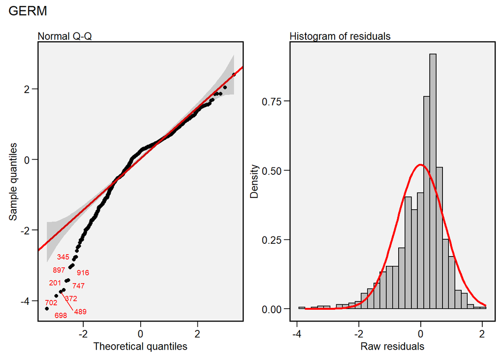

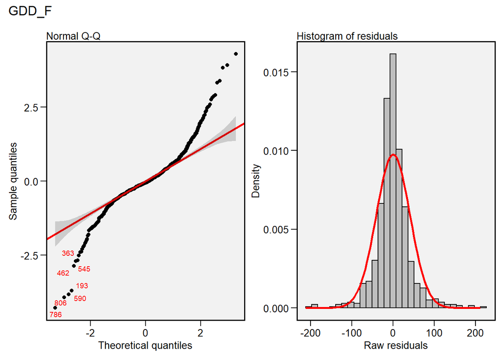

```r
par(mfrow=c(1,2))

plot(gen_alphaR18,  which = c(2,5), labels = TRUE, var = 1)
plot(gen_alphaR18,  which = c(2,5), labels = TRUE, var = 4)
```

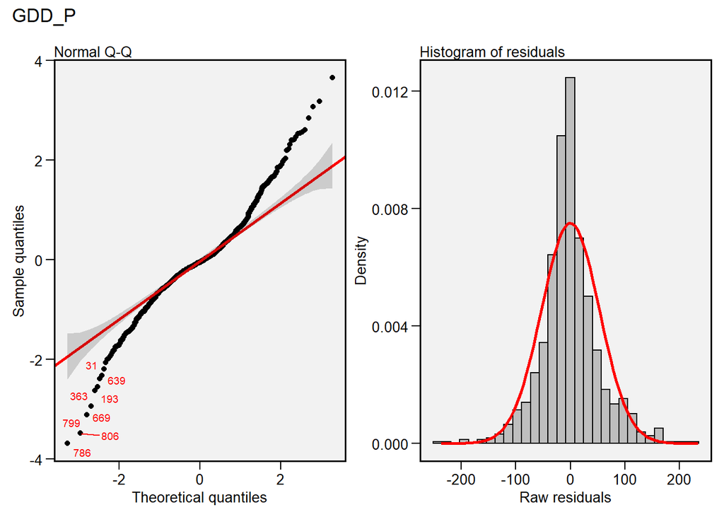

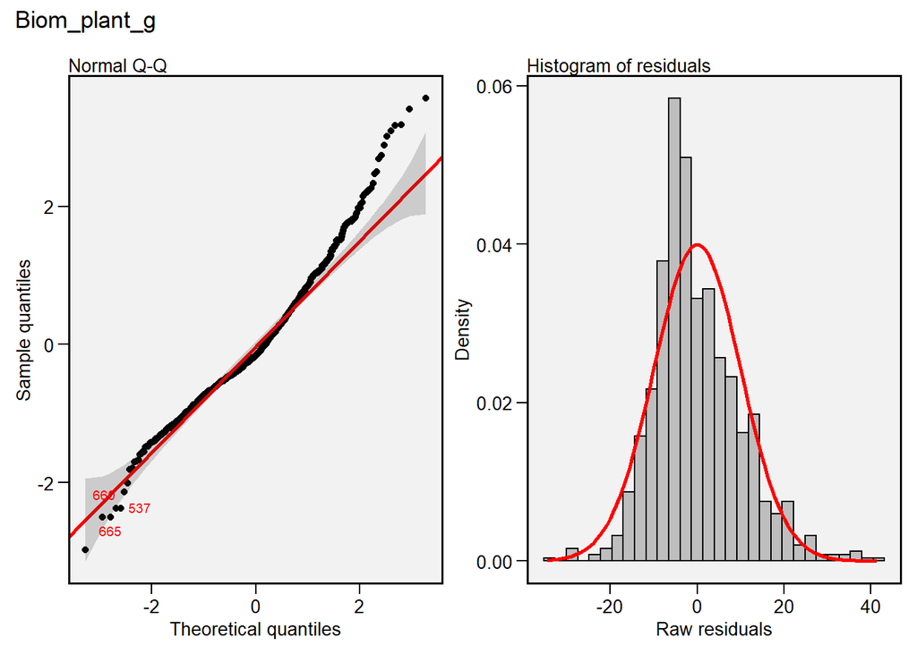

```r
par(mfrow=c(1,2))
plot(gen_alphaR18,  which = c(2,5), labels = TRUE, var = 5)
plot(gen_alphaR18,  which = c(2,5), labels = TRUE, var = 6)
```

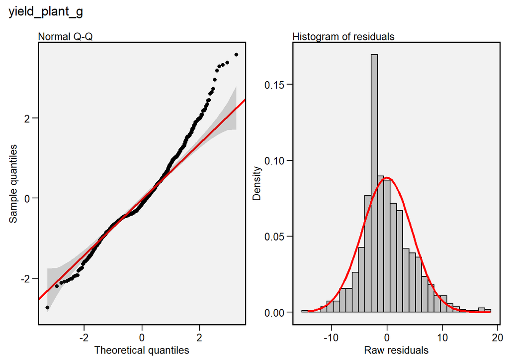

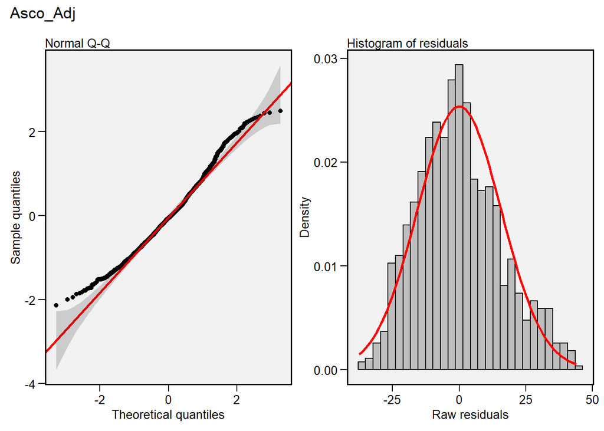

```r
par(mfrow=c(1,2))
plot(gen_alphaR18,  which = c(2,5), labels = TRUE, var = 7)
plot(gen_alphaR18,  which = c(2,5), labels = TRUE, var = 8)
```

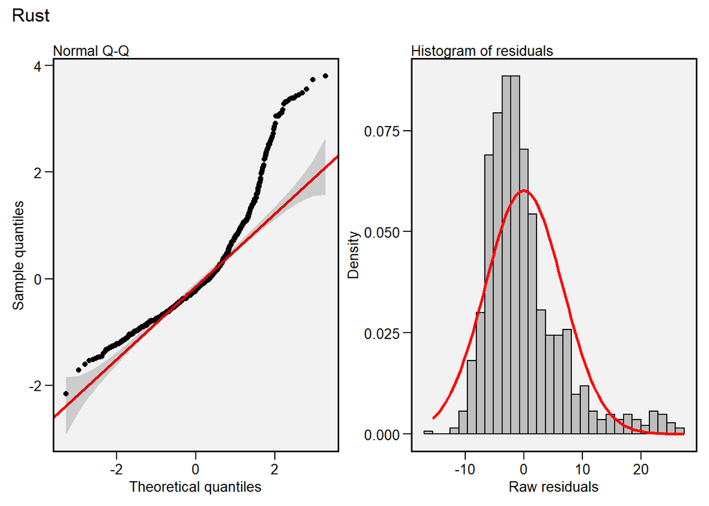

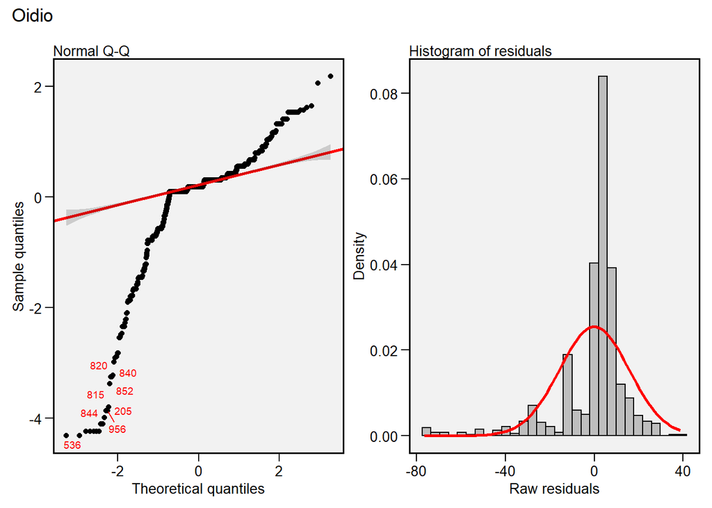

```r
par(mfrow=c(1,2))
plot(gen_alphaR18,  which = c(2,5), labels = TRUE, var = 9)
plot(gen_alphaR18,  which = c(2,5), labels = TRUE, var = 11)
```

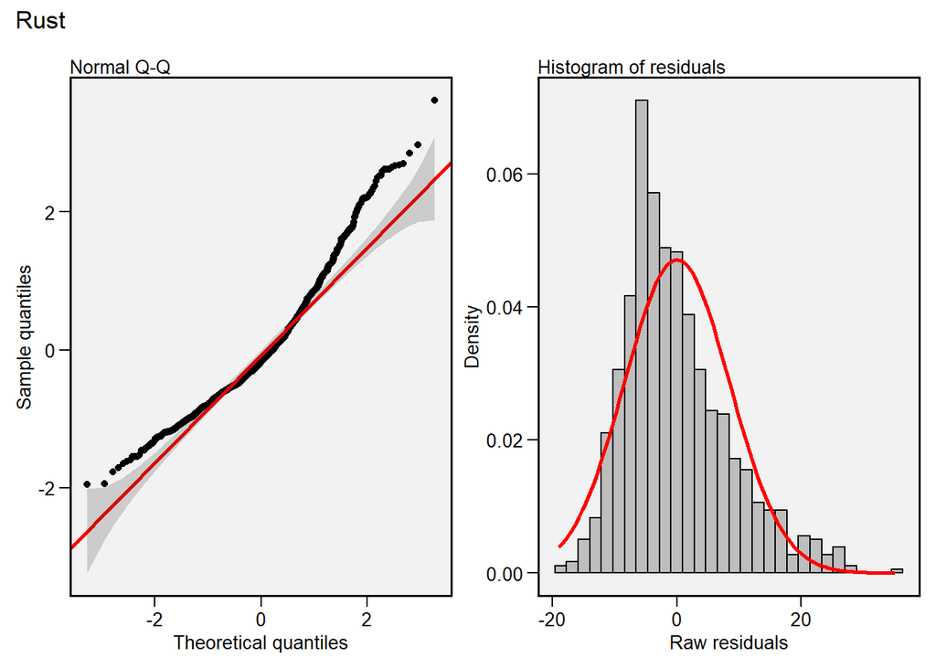

```r
plot(gen_alphaR19,  which = c(2,5), labels = TRUE, var = 9)
```

**Correlation between traits in season 2018:**

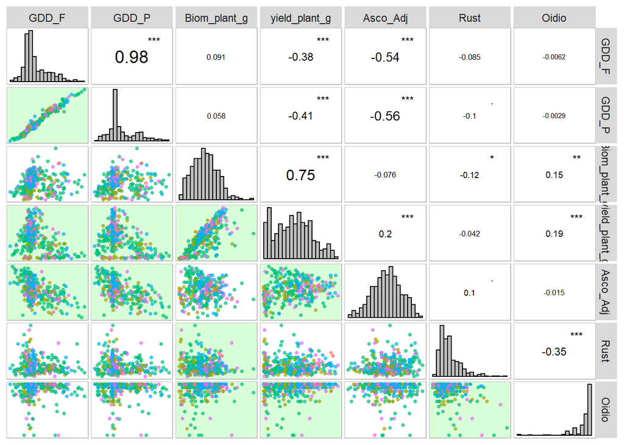

```r
material <- select(R18_nc, c(5,6))
material <- material[1:323,1:2]

BLUP18 <- as.data.frame(get_model_data(gen_alphaR18, "blupg"))
BLUP18 <-cbind(BLUP18, material)
corr_plot(BLUP18, GDD_F, GDD_P, Biom_plant_g, yield_plant_g, Asco_Adj, Rust, Oidio, col.by = Material)
```

**Correlation between traits in season 2019:**

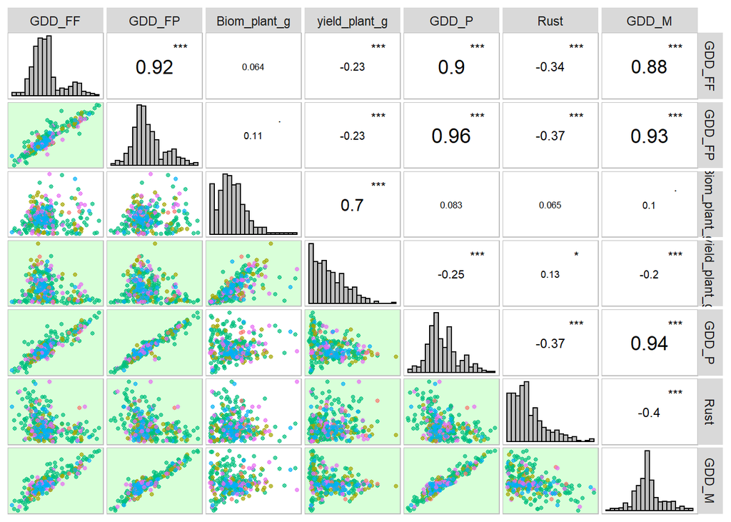

```r
material19 <- select(R19_nc, c(5,6))
material19 <- material[1:322,1:2]

BLUP19 <- as.data.frame(get_model_data(gen_alphaR19, "blupg"))
BLUP19 <-cbind(BLUP19, material19)
corr_plot(BLUP19, GDD_FF, GDD_FP, Biom_plant_g, yield_plant_g, GDD_P, Rust, GDD_M, col.by = Material)
```

**Response to rust by Material or Specie in season 2018:**

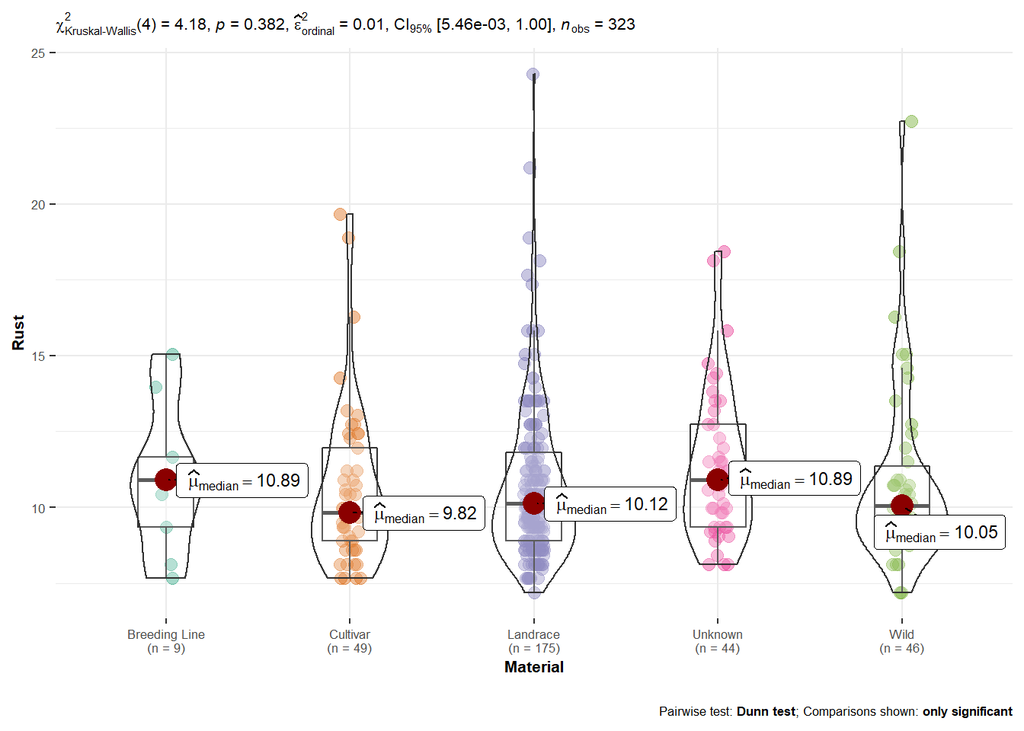

```r
ggbetweenstats(x = Material, y = Rust, data = BLUP18,
               p.adjust.method = "none", type = "np",
               bf.message = FALSE, var.equal = F,
               ggsignif.args = list(textsize = 1.5, tip_length = 0.01)) +
  theme(text = element_text(size = 8), plot.subtitle = element_text(size=8))
```

**Response to rust by Material or Specie in season 2019:**

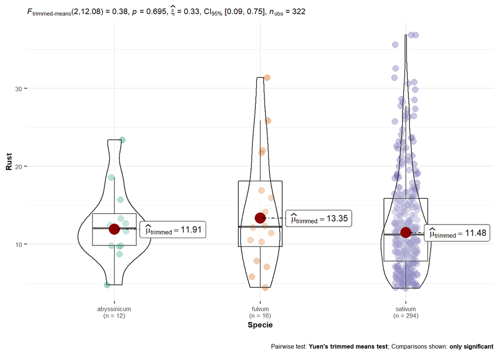

```r
ggbetweenstats(x = Specie, y = Rust, data = BLUP19,
               p.adjust.method = "bonferroni", type = "robust",
               bf.message = FALSE, var.equal = F,
               ggsignif.args = list(textsize = 1.5, tip_length = 0.01)) +
  theme(text = element_text(size = 8), plot.subtitle = element_text(size=8))
```